# 52414 - lab 1

52414

27/4/2021

# *Lab 1: Basic Data Wrangling and Plotting*

**Submission Deadline: 19/5/2021 at 23:59**

## Analysis of the World Covid-19 Dataset

**Solution:**

Write your solutions here seperately for each question in the followng format:

1. Loading the data and change it to date class

```r
full_dataset <- read.csv(url("https://covid.ourworldindata.org/data/owid-covid-data.csv"),header = T, comment.char = "#")
print(class(full_dataset$date))  ### need change to date format
```

```
## [1] "character"
```

```r
full_dataset$date<-as.Date(full_dataset$date)
print(class(full_dataset$date))
```

```
## [1] "Date"
```

2. We choiced the needed column and then ordered them according to data (to have only the newest date), then we chose only unique countries and then we ordered it in decreasing order to display top 5.

```r
top_5_casesm <- full_dataset[,c(3,4,11)]
top_5_casesm <- na.omit(top_5_casesm)
top_5_casesm <- top_5_casesm[order(top_5_casesm$date,decreasing = T),]
my_date <- unique(top_5_casesm$date)[1]
top_5_casesm <- top_5_casesm[top_5_casesm$date==my_date,]
top_5_casesm <- top_5_casesm[order(top_5_casesm$total_cases_per_million,decreasing = T),]
head(top_5_casesm,5)
```

```
##         location       date total_cases_per_million
## 2282     Andorra 2021-05-24                175616.4
## 55352 Montenegro 2021-05-24                158091.1
## 21602    Czechia 2021-05-24                154831.9
## 70502 San Marino 2021-05-24                149949.9
## 7041     Bahrain 2021-05-24                129789.1
```

```r
top_5_deathsm <- full_dataset[,c(3,4,14)]
top_5_deathsm <- na.omit(top_5_deathsm)
top_5_deathsm <- top_5_deathsm[order(top_5_deathsm$date,decreasing = T),]
top_5_deathsm <- top_5_deathsm[top_5_deathsm$date==my_date,]
top_5_deathsm <- top_5_deathsm[order(top_5_deathsm$total_deaths_per_million,decreasing = T),]
head(top_5_deathsm,5)
```

```
##                     location       date total_deaths_per_million
## 37182                Hungary 2021-05-24                 3059.931
## 21602                Czechia 2021-05-24                 2804.001
## 11174 Bosnia and Herzegovina 2021-05-24                 2788.941
## 70502             San Marino 2021-05-24                 2651.895
## 61014        North Macedonia 2021-05-24                 2557.863
```

```r
top_5_vaccinated <- full_dataset[,c(3,4,40)]
top_5_vaccinated <- na.omit(top_5_vaccinated)
top_5_vaccinated <- top_5_vaccinated[order(top_5_vaccinated$date,decreasing = T),]
top_5_vaccinated <- top_5_vaccinated[top_5_vaccinated$date==my_date,]
top_5_vaccinated <- top_5_vaccinated[order(top_5_vaccinated$total_vaccinations_per_hundred,decreasing = T),]
head(top_5_vaccinated,5)
```

```
##          location       date total_vaccinations_per_hundred
## 40994      Israel 2021-05-24                         122.05
## 4271        Aruba 2021-05-24                         102.80
## 40534 Isle of Man 2021-05-24                          98.59
## 7041      Bahrain 2021-05-24                          94.13
## 34072    Guernsey 2021-05-24                          91.96
```

3A.We got rid of the locations that are not applicable to our questions than we draw a ggplot.

```r
options(scipen=999)
myfun = function(df,col_name){
  relevant_df <-df %>% drop_na(all_of(col_name)) %>% filter((continent=="") & location != "International" & location != "World" & location != "European Union")
  ggplot(relevant_df,aes_string(y=col_name,col="location"))+
    geom_line(aes(x=as.Date(date)))+
    ylab(as.character(col_name)) +xlab("Date")+
    ggtitle(label="Continents distribution by date",subtitle = as.character(col_name))}
```

The results went out really hard to read and analyze. The plot have a lot of peacks and its hard to see the treand, it is really dense.

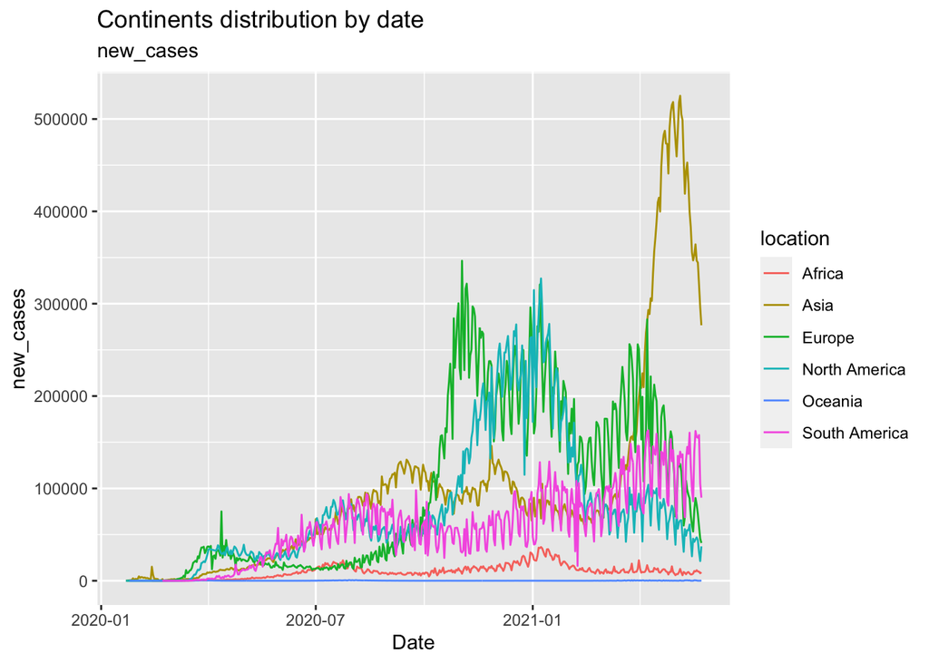

```r
myfun(full_dataset,"new_cases")
```

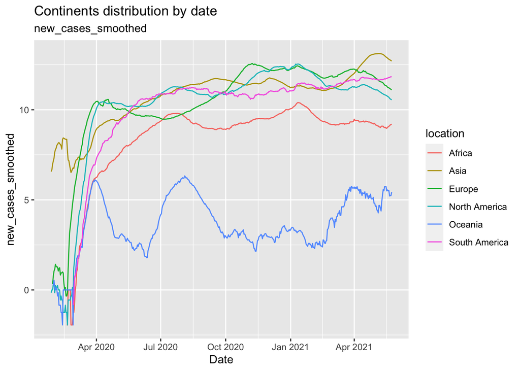

```r
### log function does not apply to nonpositive numbers including 0, hence we will replace <= 0 by 1 (since log(1)=0)
log_smooth <- full_dataset
log_smooth$new_cases_smoothed <- replace(log_smooth$new_cases_smoothed, log_smooth$new_cases_smoothed<=0,1)
log_smooth$new_cases_smoothed <- log(log_smooth$new_cases_smoothed)
myfun(log_smooth,"new_cases_smoothed")
```

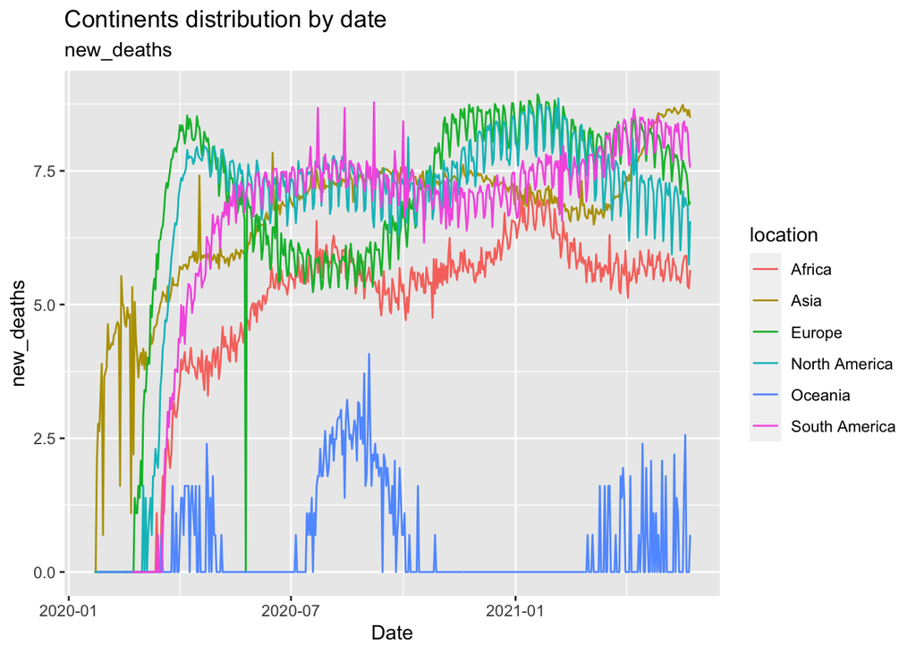

```r
log_deaths <- full_dataset
log_deaths$new_deaths <- replace(log_deaths$new_deaths, log_deaths$new_deaths<=0,1)
log_deaths$new_deaths <- log(log_deaths$new_deaths)
myfun(log_deaths,"new_deaths")
```

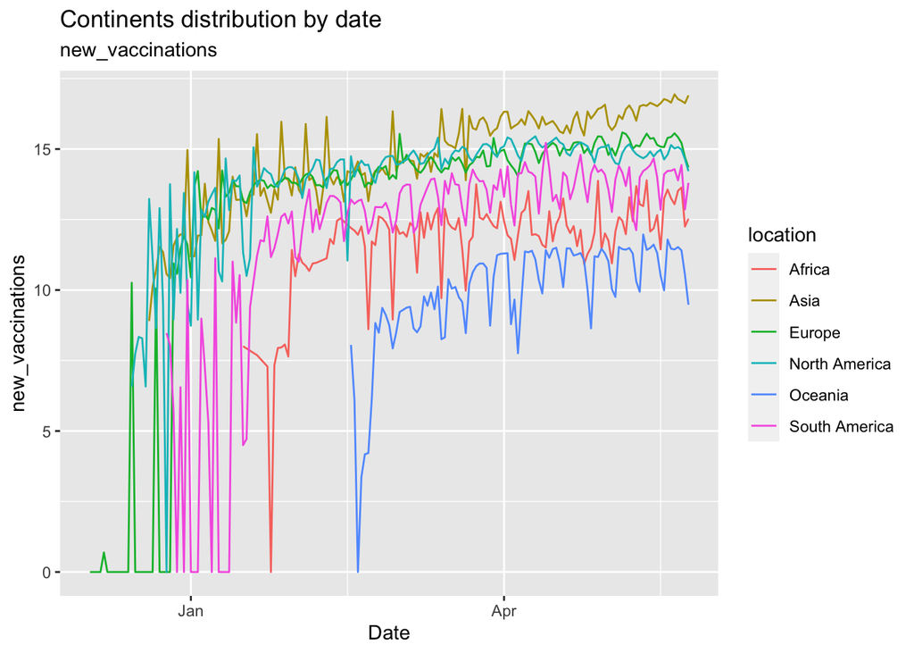

```r
log_vaccinated <- full_dataset
log_vaccinated$new_vaccinations <- replace(log_vaccinated$new_vaccinations, log_vaccinated$new_vaccinations<=0,1)
log_vaccinated$new_vaccinations <- log(log_vaccinated$new_vaccinations)
myfun(log_vaccinated,"new_vaccinations")
```

The smooth log graph is easier to read and analyze since it is not that saturated and does not have that much peaks. We had to replace values that are equals or smaller than 0 (log is not defined there), that is why the graph is not that precise as original one. Howver, now we can observe the trends.

4A.We started with filtering data frame to have country level data. Then we did continent vector, NA changed to 0 so they won’t interfere. Then we aggragted the new dataframe by date, so now we received new data for every continent .

```r
myfunction = function(df,col){
  df<-df%>%filter((continent!="") & (location != "World"))
  continents=c("Africa","Asia","Europe","North America","Oceania","South America")
  continent.df<- data.frame()
  for (i in c(continents)){
    x <- df %>% filter(continent == i| location == i)
    x <- x[c("date",col)]
    x[is.na(x)]=0
    colnames(x)=c("date","x")
    aggt=aggregate(x$x, by=list(x$date), sum)
    aggt$continent=i
    continent.df <- rbind(continent.df,aggt)}
colnames(continent.df)=c("date",all_of(col),"continent")
return(continent.df)
}
```

4B.We applied the function from a and filled the new_tests_smoothed column

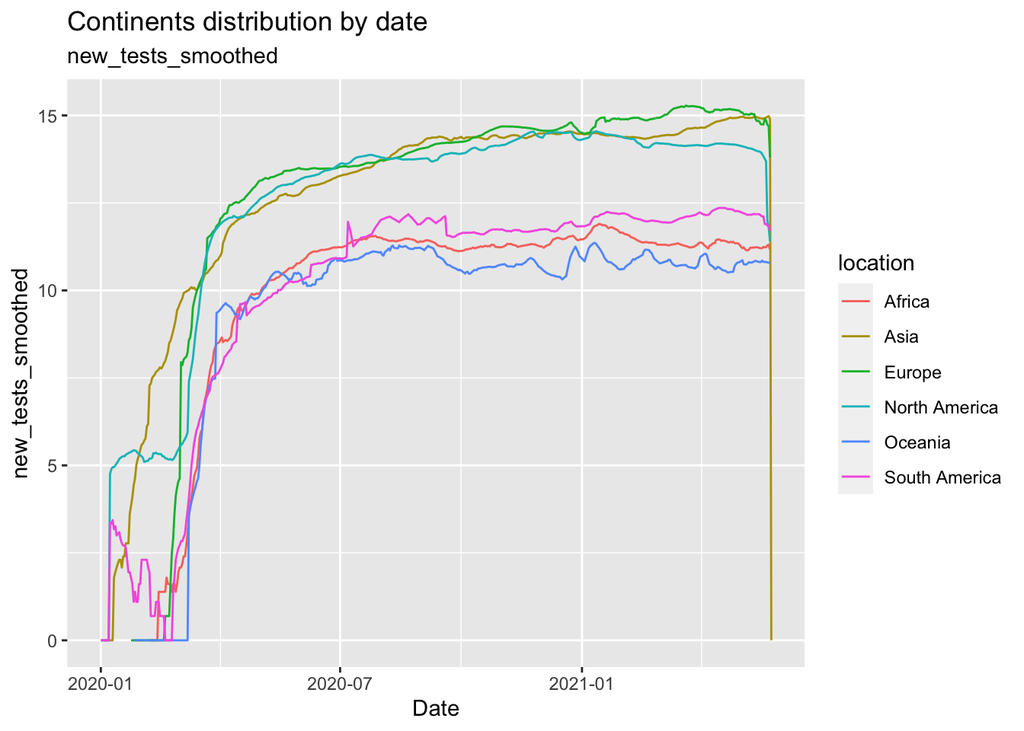

```r
applied_smooth_test <- myfunction(full_dataset,"new_tests_smoothed")
applied_smooth_test$new_tests_smoothed <- replace(applied_smooth_test$new_tests_smoothed,applied_smooth_test$new_tests_smoothed<=0,1)
applied_smooth_test$new_tests_smoothed <- log(applied_smooth_test$new_tests_smoothed)
applied_smooth_test$location <- applied_smooth_test$continent  ### arbitrary location to apply fun of question 3 here
applied_smooth_test$continent = "" ### remove the duplicated column
myfun(applied_smooth_test,"new_tests_smoothed")
```

The log graph is smoother than previous one so it is easier to read and analyze it.

5A. We created a new data frame for every country with columns total_cases_per_M, total_deaths_per_M, then we did a plot based on our dataframe and calculated a regression line.

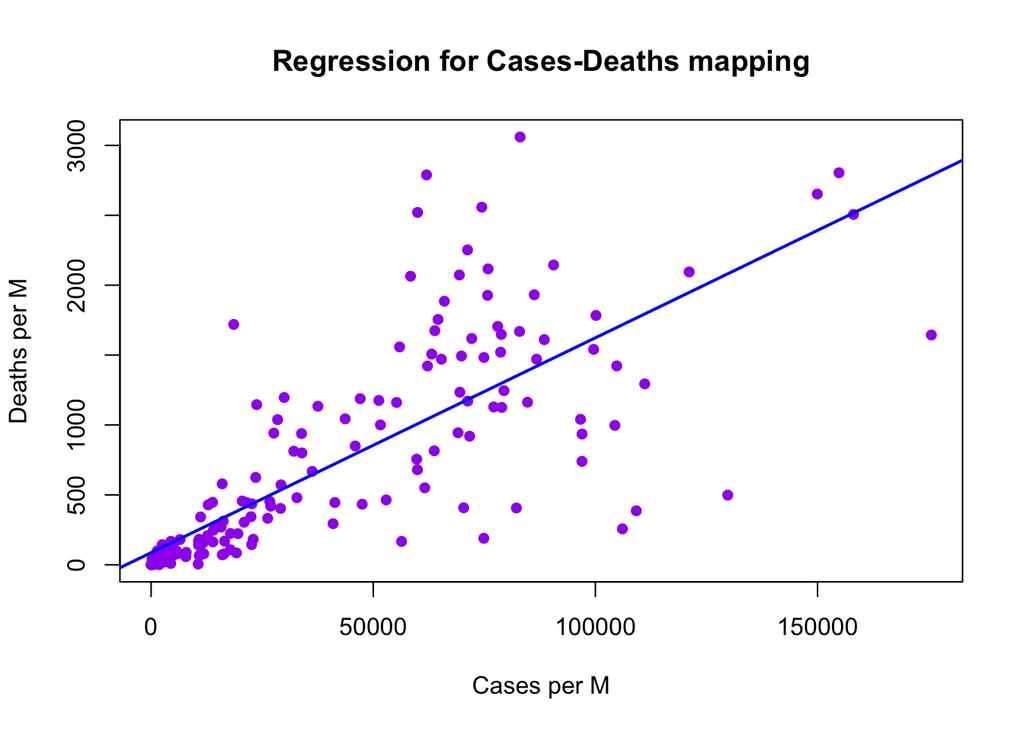

```r
country_names <- unique(full_dataset$location)
uniq_country_df <- cbind(country_names,rep(0,length(country_names)),rep(0,length(country_names)))
colnames(uniq_country_df) <- c("location","total_cases_per_M","total_deaths_per_M")
arbitrary_df <- full_dataset[,c(3,11,14)]
arbitrary_df <- na.omit(arbitrary_df)
for(i in 1:length(country_names)){
  uniq_country_df[i,2] <- max(arbitrary_df[arbitrary_df$location==country_names[i],2])
  uniq_country_df[i,3] <- max(arbitrary_df[arbitrary_df$location==country_names[i],3])
}
### remove the non maximum rows
uniq_country_df[uniq_country_df==-Inf]<-NA
uniq_country_df<- na.omit(uniq_country_df)
uniq_country_df <- as.data.frame(uniq_country_df)
uniq_country_df$total_cases_per_M <- as.numeric(uniq_country_df$total_cases_per_M)
uniq_country_df$total_deaths_per_M <- as.numeric(uniq_country_df$total_deaths_per_M)

plot(uniq_country_df$total_cases_per_M,uniq_country_df$total_deaths_per_M,xlab = "Cases per M",ylab = "Deaths per M",main = "Regression for Cases-Deaths mapping",col="purple",pch=16)
abline(lm(uniq_country_df$total_deaths_per_M ~ uniq_country_df$total_cases_per_M),col="blue",lwd=2)
```

```r
my_reg <- lm(uniq_country_df$total_deaths_per_M ~ uniq_country_df$total_cases_per_M)
cat("The slope is the beta_1 which is:", my_reg$coefficients[2])
```

```
## The slope is the beta_1 which is: 0.01537349
```

$\beta_1$ represent in our case the effect (or the realationship) of cases per millions on death per millions. in our case we would expect that for each case of covid in a specific country, the deaths will increase by 0.015 units (which is very logical since for each case there is a chance of death).

5B.By selecting we found out the date on which were the max amount of cases and deaths for every country and then added to a new datafram using a. Then we did plot and draw regreassion line.

```r
cases <- full_dataset %>%  select(location,new_cases,date) %>% group_by(location) %>% top_n(1,new_cases) %>% top_n(1,date)
death <- full_dataset %>%  select(location,new_deaths,date) %>%group_by(location) %>% top_n(1,new_deaths) %>% top_n(1,date)

group_all <- full_join(cases,death, by="location") %>% na.omit()

reg <- lm(as.matrix(date.y)~as.matrix(date.x), group_all)
summary(reg)
```

```
##
## Call:
## lm(formula = as.matrix(date.y) ~ as.matrix(date.x), data = group_all)
##
## Residuals:
##     Min      1Q  Median      3Q     Max
## -332.31  -40.31   24.67   58.51  275.68
##
## Coefficients:
##                     Estimate Std. Error t value            Pr(>|t|)
## (Intercept)       7614.01203 1251.97560   6.082 0.00000000635829091 ***
## as.matrix(date.x)    0.59073    0.06717   8.795 0.00000000000000084 ***
## ---
## Signif. codes:  0 '***' 0.001 '**' 0.01 '*' 0.05 '.' 0.1 ' ' 1
##
## Residual standard error: 102.3 on 191 degrees of freedom
## Multiple R-squared:  0.2882, Adjusted R-squared:  0.2845
## F-statistic: 77.34 on 1 and 191 DF,  p-value: 0.0000000000000008398
```

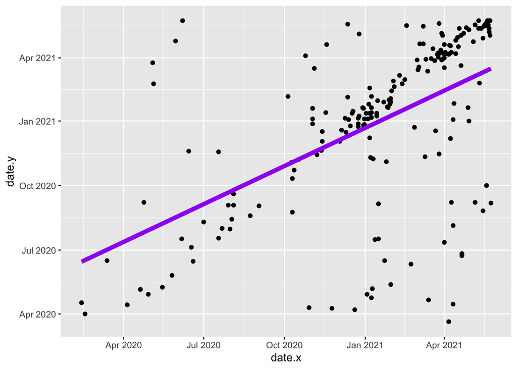

```r
ggplot(data=group_all, mapping=aes(x=date.x,y=date.y))+geom_point()+geom_smooth(method="lm",se=F,col="purple",lwd=2)
```

6.We made a new dataframe, we put 0 instead of NA to understand the development of cases, deaths and vaccinations by month. Then we aggreagated helper dataset, deleted from it columns that reapet each other and rename columns. Then using new dataset we draw plot.

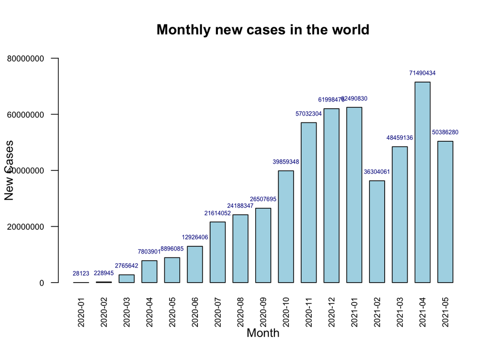

```r
helper_df <-data.frame(full_dataset$location,full_dataset$date,full_dataset$new_cases, full_dataset$new_deaths, full_dataset$new_vaccinations)
helper_df[is.na(helper_df)] <- 0 ##we put 0,where there is no info(for e.g. about vaccination)to have a full picture
date_months = strftime(helper_df$full_dataset.date, "%Y-%m") #compile to monthly count


helper_df$full_dataset.new_cases <- as.numeric(helper_df$full_dataset.new_cases)
helper_df$full_dataset.new_deaths<-as.numeric(helper_df$full_dataset.new_deaths)
helper_df$full_dataset.new_vaccinations <- as.numeric(helper_df$full_dataset.new_vaccinations)


cases.agg <- aggregate(full_dataset.new_cases~date_months, data = helper_df, FUN = sum)
deaths.agg <- aggregate(full_dataset.new_deaths~date_months, data = helper_df, FUN = sum)
vaccinated.agg <- aggregate(full_dataset.new_vaccinations~date_months, data = helper_df, FUN = sum)

monthly = data.frame(cases.agg, deaths.agg,vaccinated.agg)
to.remove <- c('date_months.1', 'date_months.2')
monthly <- monthly[, !colnames(monthly) %in% to.remove] #remove doubled columns with date
colnames(monthly) <- c("months","new_cases","new_deaths","new_vaccinations")


###drawing a barplot
options(scipen=999)
monthly_new_cases<-barplot(monthly$new_cases,
        main= "Monthly new cases in the world",
        xlab = "Month",
        ylab= "New Cases",
        ylim=c(0,80000000),
        col = "lightblue",
        space=0.5,
        width=50,
        names.arg = monthly$months,las=2, cex.axis = 0.7, cex.names = 0.7)
text(x=monthly_new_cases,y=monthly$new_cases,label=monthly$new_cases, pos=3, cex=0.5, col="darkblue")
```

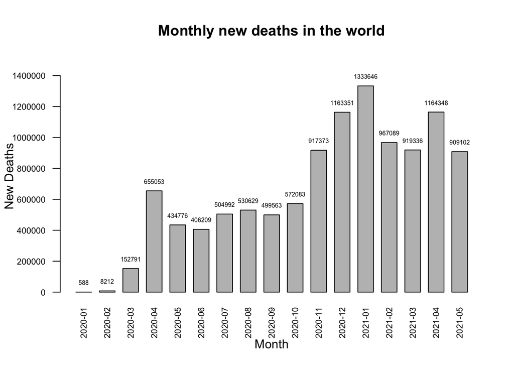

```r
options(scipen=999)
monthly_new_deaths<-barplot(monthly$new_deaths,
        main= "Monthly new deaths in the world",
        xlab = "Month",
        ylab= "New Deaths",
        ylim=c(0,1500000),
        col = "grey",
        space=0.5,
        width=50,
        names.arg = monthly$months, cex.axis = 0.7, cex.names = 0.7, las=2)
text(x=monthly_new_deaths,y=monthly$new_deaths,label=monthly$new_deaths, pos=3, cex=0.5, col="black")
```

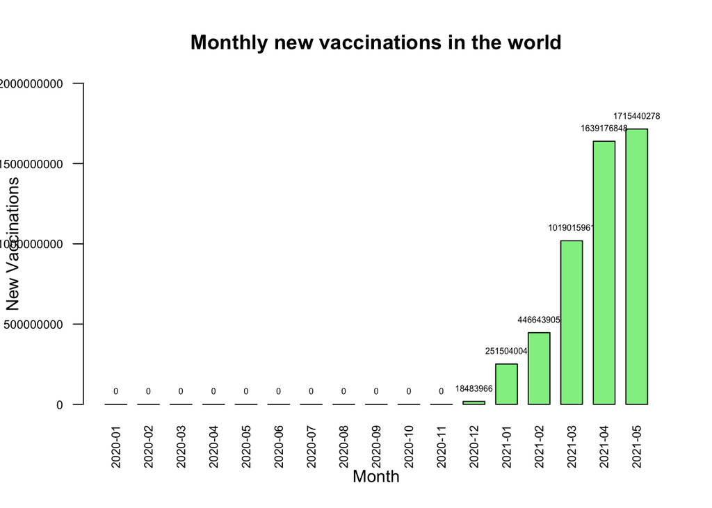

```r
options(scipen=999)
monthly_new_vaccinations<-barplot(monthly$new_vaccinations,
        main= "Monthly new vaccinations in the world",
        xlab = "Month",
        ylab= "New Vaccinations",
        col = "lightgreen",
        ylim=c(0,2000000000),
        space=0.5,
        width=50,
        names.arg = monthly$months, cex.axis = 0.7, cex.names = 0.7, las=2)
text(x=monthly_new_vaccinations,y=monthly$new_vaccinations,label=monthly$new_vaccinations, pos=3, cex=0.5, col="black")
```

7. We added to the covid data-frame a new column called death_rate, defined for location and date as the number of total_deaths divided by the number of total_cases. This column represents the probability of a diagnosed Covid-19 case to die from the disease. Next, we made a histogram of the current death rates over all countries with 50 bins. And displayed in a table the top 3 countries having the highest death rate.

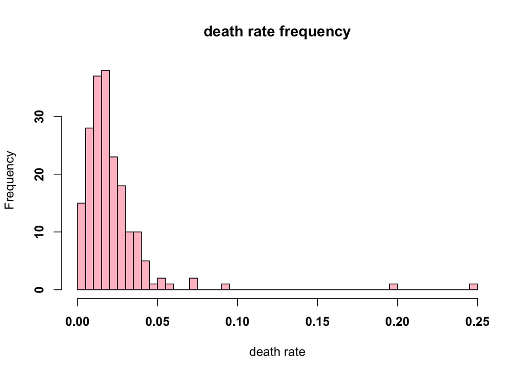

```r
death_rate=c(full_dataset$total_deaths)/c(full_dataset$total_cases)
full_dataset=cbind(full_dataset,death_rate)
temp1 <-  aggregate(total_deaths~location,full_dataset,FUN = max)
temp2 <-  aggregate(total_cases~location,full_dataset,FUN = max)
tempdata <- full_join(temp1,temp2, by = "location")
tempdata$death_rate=tempdata$total_deaths/tempdata$total_cases

hist(tempdata$death_rate, breaks=50, main="death rate frequency",xlab = "death rate",col="pink", font.axis=2)
```

```r
top3deathrate <- tempdata
top3deathrate <- top3deathrate[with(top3deathrate,order(-death_rate)),]
top3deathrate <- top3deathrate[1:3,]
top3=data.frame("countries"=c(as.character(top3deathrate$location)),"death_rate"=c(top3deathrate$death_rate))
t=setDT(top3)
t
```

```
##    countries death_rate
## 1:   Vanuatu 0.25000000
## 2:     Yemen 0.19663765
## 3:    Mexico 0.09247668
```

8.We created an additional column called two_dose_fraction, defined as the number of fully vaccinated people divided by the number of vaccinated people. Next, we plotted for Israel, United Kingdom and United States this value as a function of date, on the same plot with different colors.

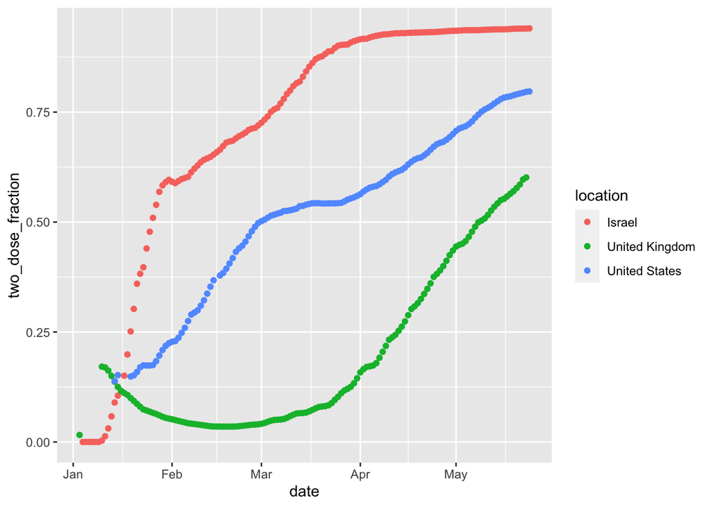

```r
full_dataset$two_dose_fraction = full_dataset$people_fully_vaccinated/full_dataset$people_vaccinated
selected_countries <- full_dataset %>% select(location, date, two_dose_fraction) %>% na.omit() %>% subset( location == "Israel" |location =='United Kingdom'|location =='United States')

ggplot(selected_countries, aes(x=date, y=two_dose_fraction))+geom_point(aes(color = location))
```

9A.The function recieves as input the data-frame, a country name and the name of two columns, and computes the value of their cross-correlation in this country for time delay of up to two months apart, that is for all values of $\Delta_t$ between $-60$ days and $60$ days. The function return a vector of length $121$ representing these correlations. We started with matrix, then we made a loop to filter and select what is needed, and then did the vector.

```r
myfun.9 <- function(df,country,col1,col2){
  location_req <- filter(df,location== country)
  teamp1 <- location_req[[col1]]
  teamp2 <- location_req[[col2]]
  min <- min(location_req$date)
  max <- max(location_req$date)
  cross <- c()
  for(c in seq(60,0,-1)){
    delta_Ty <- seq(min,max-c,by="days")
    delta_Tx <- seq(min+c,max,by="days")
    x <- location_req %>% filter(date %in% delta_Tx) %>%  select(col1)
    y <- location_req %>% filter(date %in% delta_Ty) %>%  select(col2)
    cross <- c(cross, cor(y,x,use="complete.obs"))}
    for(c in seq(1,60,1)){
    delta_Tx <- seq(min,max-c,by="days")
    delta_Ty <- seq(min+c,max,by="days")
    x <- location_req %>% filter(date %in% delta_Tx) %>%  select(col1)
    y <- location_req %>% filter(date %in% delta_Ty) %>%  select(col2)
    cross <- c(cross, cor(x,y,use="complete.obs"))}
return(cross)}
```

9B. It Computes the cross correlation between the number of `new_cases` and `new_deaths` for *Canada*, and plot it as a function of $\Delta_t$.

```r
canada <- myfun.9(full_dataset,"Canada","new_cases","new_deaths")
```

```
## Note: Using an external vector in selections is ambiguous.
## ℹ Use `all_of(col1)` instead of `col1` to silence this message.
## ℹ See <https://tidyselect.r-lib.org/reference/faq-external-vector.html>.
```

```
## Note: Using an external vector in selections is ambiguous.
## ℹ Use `all_of(col2)` instead of `col2` to silence this message.
## ℹ See <https://tidyselect.r-lib.org/reference/faq-external-vector.html>.
```

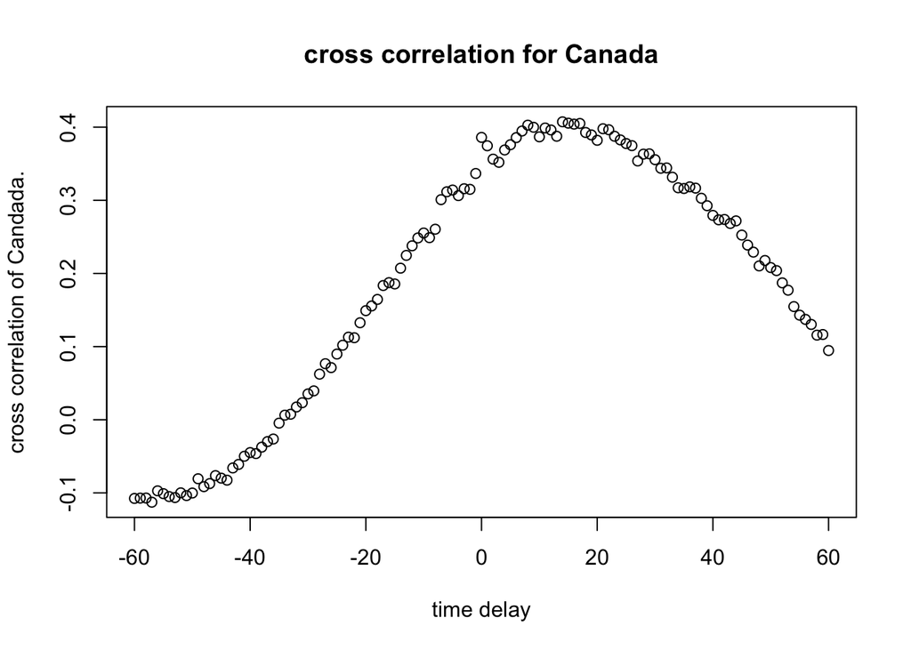

```r
plot(seq(-60,60,1), canada, main= 'cross correlation for Canada', xlab='time delay', ylab='cross correlation of Candada.')
```

Time delay according to plot is 17 days(which is the peak), this is means that it takes 17 days in Canada from moment of infection to death.

10.We aggregated the needed data, than comlied datasets together by “location”, then we draw plot and higlighted Israel and United Kindom.

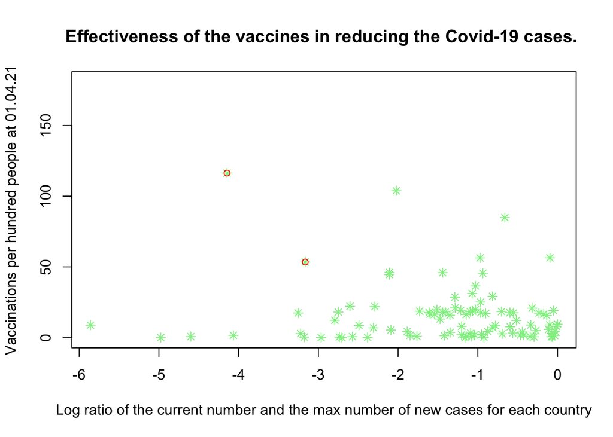

```r
max_smoothed <- aggregate(new_cases_smoothed~location,full_dataset,FUN = max)
current_cases <- full_dataset %>% filter(date == '2021-04-23') %>% select(location,new_cases_smoothed)
total_vacc_per_hun <- full_dataset %>% filter(date == '2021-04-01') %>% select(location,total_vaccinations_per_hundred)
names(max_smoothed)[2]<-paste("maximal_cases_smoothed")
names(current_cases)[2]<-paste("current_cases_smoothed")



effect_data<-full_join(current_cases,max_smoothed,ratio, by = "location")
effect_data$current_cases_smoothed<-as.numeric(effect_data$current_cases_smoothed)
effect_data$maximal_cases_smoothed<-as.numeric(effect_data$maximal_cases_smoothed)
effect_data <- mutate(effect_data, ratio = current_cases_smoothed/maximal_cases_smoothed)
effect_data <- full_join(effect_data, total_vacc_per_hun,by = "location")

#Drawing a plot
monthly_new_vaccinations<-plot(x=log(effect_data$ratio), y=effect_data$total_vaccinations_per_hundred,
        main= "Effectiveness of the vaccines in reducing the Covid-19 cases. ",
        xlab = "Log ratio of the current number and the max number of new cases for each country",
        ylab= "Vaccinations per hundred people at 01.04.21",
        col = "lightgreen",
        pch=8)

outliers <- effect_data %>%  subset( location == "Israel" |location =='United Kingdom')
with(outliers, points(log(ratio), total_vaccinations_per_hundred, cex=.9, col='red'))
```

```r
#with(outliers, text(log(ratio)~total_vaccinations_per_hundred, labels=location, cex=1, pos=4, col='red'))
```

the general conclusion is that with the rise of vaccinated people the ratio is becomg less, consequntly, the vacconation is effcetive. Scattered results can be explained because of the usage of different vaccines(effectivness of different vaccines differ) by countries, population structure in countries (may be vaccine have a different effect on different generations). However, the results of vaccination in United Kindom and Israel is very effective comaring to other countries, since they have one of the lowest ratios and one of the highest vaccination levels).